# gsw

Dan Kelley (https://orcid.org/0000-0001-7808-5911) and Clark Richards (https://orcid.org/0000-0002-7833-206X)

2024-08-19

**Abstract.** The `gsw` package provides an R implementation of the Gibbs SeaWater toolbox for the calculation of seawater properties, based on the GSW-C framework[^1]. This vignette outlines how to use `gsw` alone or as part of the `oce` package (Kelley, Richards, and Layton 2021).

# 1 Introduction

In recent years, thermodynamic considerations have led to improved formulae for the calculation of seawater properties (IOC, SCOR, and IAPSO 2010; Millero 2010; Pawlowicz et al. 2012), an important component of which is the Gibbs-SeaWater (GSW) toolbox (McDougall and Barker 2020). The `gsw` package is an R version of GSW, which may be used independently or within the more general `oce` package (Kelley, Richards, and Layton 2021).

This vignette sketches how to use `gsw`. Readers are assumed to be familiar with oceanographic processing, and at least somewhat familiar with GSW. A good resource for learning more about GSW is http://www.teos-10.org, which provides technical manuals for the Matlab version of GSW http://www.teos-10.org/pubs/gsw/html/gsw_contents.html, along with white papers and links to the growing peer-reviewed literature on the topic.

The `gsw` framework uses function wrappers that connect R with the C version of the Gibbs Seawater library. This yields high processing speed. By minimizing transliteration errors, it also increases reliability. In a further effort to increase reliability, GSW-R makes tests against the check values provided on the webpages that document GSW-Matlab.

By design, the documentation of `gsw` functions is spare, amounting mainly to an explanation of function arguments and return values, with most other details being provided through hyperlinks to the GSW reference documentation. The idea is to avoid duplication and to encourage users to consult the technical materials linked to the GSW functions mimicked in `gsw`. The GSW system is somewhat complex, and analysts owe it to themselves to learn how it works, and also to develop an appreciation for its scientific context by consulting various documents at http://www.teos-10.org, including expansive white papers and pointers to the growing peer-reviewed literature (Wright et al. 2011; McDougall and Barker 2020; Graham and McDougall 2012).

# 2 Using gsw independent of oce

Suppose a water sample taken at pressure (For practical reasons, `gsw` goes beyond SI to incorporate oceanographic units, such as decibars for pressure.) 100 dbar, longitude 188E and latitude 4N, reveals Practical Salinity 35 and in-situ temperature 10$^\circ$C (ITS-90). Then the Absolute Salinity may be calculated as follows.

```r
library(gsw)
SA <- gsw_SA_from_SP(SP=35, p=100, longitude=188, latitude=4)
```

This yields `SA`=35.1655491 [g/kg], which can then be used to calculate Conservative Temperature as follows.

```r
CT <- gsw_CT_from_t(SA=SA, t=10, p=100)
```

The above yields `CT`=9.9782488 [$^\circ$C]. Readers familiar with GSW will recognize the function and argument names, and are likely to find the other functions needed for their work among the roughly sixty functions that `gsw` provides.

# 3 Using gsw within oce

Many `oce` plotting functions have an argument named `eos` that can be set to the string `"unesco"` to get the older seawater formulation, or to `"gsw"` to get the newer one. For example, the `section` dataset provided by `oce` holds a sequence of CTD casts in the North Atlantic. Individual casts may be selected by index, so a TS diagram of the station at index 100 (south of Cape Cod in 4000 m of water) can be plotted as follows.

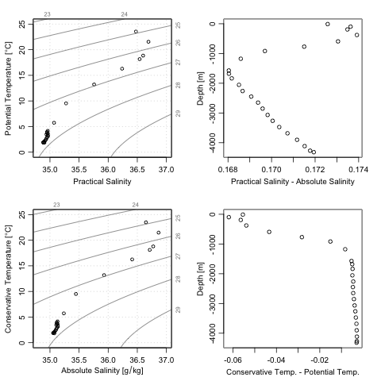

**Comparison of UNESCO and GSW equations of state, for bottle sampling at 36.3N and 69.4W in 1993. Top left: TS diagram with UNESCO equation of state, showing Potential Temperature versus Practical Salinity. Bottom left: TS diagram with GSW equation of state, showing Conservative Temperature versus Absolute Salinity. Top right: Absolute Salinity minus Practical Salinity, as a function of depth. Bottom right: Conservative Temperature minus Potential Temperature, as a function of depth.**

```r
library(oce)
data(section)
ctd <- section[["station", 100]]
Slim <- c(34.8, 37.0)
Tlim <- c(0, 25)
par(mfcol=c(2,2))
plotTS(ctd, Slim=Slim, Tlim=Tlim, eos="unesco")
plotTS(ctd, Slim=Slim, Tlim=Tlim, eos="gsw")
plot(ctd[["SA"]] - ctd[["salinity"]], ctd[["z"]],
     xlab="Practical Salinity - Absolute Salinity", ylab="Depth [m]")
plot(ctd[["CT"]] - ctd[["theta"]], ctd[["z"]],
     xlab="Conservative Temp. - Potential Temp.", ylab="Depth [m]")
```

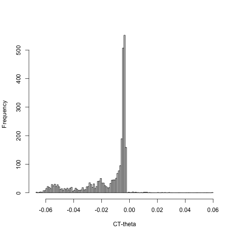

**Histogram of difference between Conservative Temperature and Potential temperature for the 124 stations of a cross-Atlantic cruise at approximately 36N.**

```r
f <- section[["CT"]] - section[["theta"]]
hist(f, main="", breaks=100, xlab="CT-theta")
```

A salinity comparison is constructed with

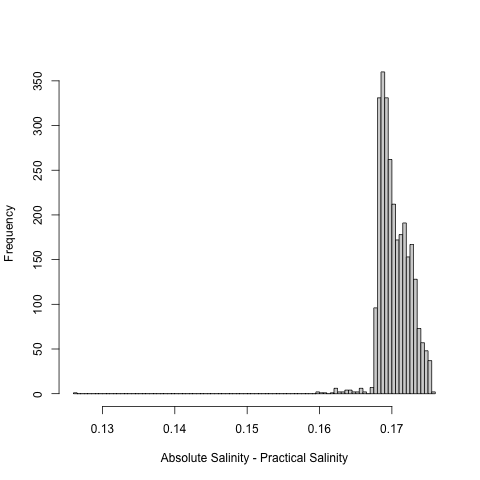

**Histogram of difference between Absolute Salinity and Practical Salinity for the 124 stations of a cross-Atlantic cruise at approximately 36N.**

```r
f <- section[["SA"]] - section[["salinity"]]
hist(f, main="", breaks=100, xlab="Absolute Salinity - Practical Salinity")
```

An examination of worldwide spatial patterns is also informative, with the following producing such a graph.

```r
library(oce)
data("levitus", package="ocedata")
SSS <- levitus$SSS
dim <- dim(SSS)
ll <- expand.grid(lon=levitus$longitude, lat=levitus$latitude)
SA <- gsw_SA_from_SP(levitus$SSS, 0, ll$lon, ll$lat)
per <- 100 * (1 - levitus$SSS / SA)
imagep(levitus$longitude, levitus$latitude, per, col=oceColorsJet,
       zlim=quantile(per, c(0.001, 0.999), na.rm=TRUE))
title(expression("Percent difference between " * S[A] * " and " * S[P]))
```

Note the use of quantile-specified scales for the images, the colour mappings of which would otherwise be controlled by isolated low-saline waters, yielding little to see in the wider expanses of the world ocean; for a broader context, see e.g. McDougall and Barker (2020).

[figure not shown]

**Map of the relative difference between Absolute Salinity and Practical Salinity at the sea surface.**

# References

Graham, Felicity S, and Trevor J McDougall. 2012. “Quantifying the Nonconservative Production of Conservative Temperature, Potential Temperature, and Entropy.” *Journal of Physical Oceanography* 43 (5): 838–62.

IOC, SCOR, and IAPSO. 2010. “The International Thermodynamic Equation of Seawater–2010: Calculation and Use of Thermodynamic Properties.” 56. UNESCO.

Kelley, Dan, Clark Richards, and Chantelle Layton. 2021. “Oce: Analysis of Oceanographic Data.” https://CRAN.R-project.org/package=oce.

McDougall, Trevor J., and Paul M. Barker. 2020. *Getting Started with TEOS-10 and the Gibbs Seawater (GSW) Oceanographic Toolbox Version 3.06.12*. SCOR/IAPSO WG127. http://www.teos-10.org/pubs/Getting_Started.pdf.

Millero, Frank. 2010. “History of the Equation of State of Seawater.” *Oceanography* 23 (3): 18–33. https://doi.org/10.5670/oceanog.2010.21.

Pawlowicz, R., T. McDougall, R. Feistel, and R. Tailleux. 2012. “Preface ’An Historical Perspective on the Development of the Thermodynamic Equation of Seawater – 2010’.” *Ocean Science* 8 (2): 161–74. https://doi.org/10.5194/os-8-161-2012.

Wright, D. G., R. Pawlowicz, T. J. McDougall, R. Feistel, and G. M. Marion. 2011. “Absolute Salinity, ‘Density Salinity’ and the Reference-Composition Salinity Scale: Present and Future Use in the Seawater Standard TEOS-10.” *Ocean Science* 7: 1–26.

[^1]: This version of GSW-R is based on GSW-C release 3.06-16-0, commit ‘657216dd4f5ea079b5f0e021a4163e2d26893371’, dated 2022-10-11; see https://github.com/TEOS-10/GSW-C.